# blblm-vignette

### blblm bootstraped linear regression function

### blblm fuction overview:

- blblm(formula, data, m = 10, B = 5000, n_cores = 1)
  - formula: here we specify the linear regression formula
  - data: a data frame
  - m: nummber of subsets of data
  - B: number of bootstraps *n_cores: if n_cores greater than 1 is inputed then perllization will be used to compute the bootstrap

```r
library(blblm)
```

- to view help for blblm:

```r
?blblm
```

```r
fit3 <- blblm(mpg ~ wt * hp, data = mtcars, m = 3, B = 100, n_cores = 3)
fit3$formula
```

```
#> mpg ~ wt * hp
```

### blblm coefficients:

- blblm(blblm_model)
  - input: here we specify the fitted blblm object
  - returns: the intercept names and coefficient estimates are returned

```r
coef(fit3)
```

```
#>      (Intercept)        wt          hp      wt:hp
#> [1,]    41.64577 -5.519676 -0.07548913 0.01394207
```

### printing blblm model details:

- blblm(blblm_model)
  - input: a fitted blblm object
  - returns: the model formula

```r
print(fit3)
```

```
#> blblm model: mpg ~ wt * hp
```

### blblm sigma:

- blblm(blblm_model)
  - input: a fitted blblm object
  - returns: the model’s sigma statistic

```r
sigma(fit3)
```

```
#> [1] 4.296899
```

### blblm sigma with confidence interval:

- blblm(blblm_model, confidence)
  - input:
    - a fitted blblm object
    - TRUE or FALSE for confidence intervals
  - returns: the model’s sigma statistic with CI or without

```r
sigma(fit3, confidence = TRUE)
```

```
#>    sigma      lwr      upr
#> 4.296899 2.969816 5.136177
```

### predicting response with new observations using blblm model:

- blblm(blblm_model, data_frame)
  - input:
    - a fitted blblm object
    - a data_frame of the new observations
  - returns: a prediction of the response variable

```r
predict(fit3, data.frame(wt = c(2.5,3) , hp = c(150, 170) ))
```

```
#>        1        2
#> 21.75148 19.36404
```

### predicting response and CI with new observations using blblm model:

- blblm(blblm_model, data_frame, confidence = TRUE/FALSE)
  - input:
    - a fitted blblm object
    - a data_frame of the new observations
    - confidence, specify TRUE to output results with CI and FALSE for no CI
  - returns: a prediction of the response variable with CI if confidence = TRUE

```r
predict(fit3, data.frame(wt = c(2.5,3) , hp = c(150, 170)), confidence = TRUE )
```

```
#>        fit      lwr      upr
#> 1 21.75148 20.48119 22.76576
#> 2 19.36404 18.22029 20.20498
```

### calculating confidence interals of coefficients:

- blblm(blblm_model, variable names)
  - input:
    - a fitted blblm object
    - variable names, if no names are specified then all coeficients CI are autimatically returned
  - returns: coeficient CI

```r
confint(fit3, c("wt", "hp"))
```

```
#> $wt
#>      2.5%     97.5%
#> -9.490204 -2.605493
#>
#> $hp
#>        2.5%       97.5%
#> -0.16057106 -0.01944137
```

```r
confint(fit3)
```

```
#> $wt
#>      2.5%     97.5%
#> -9.490204 -2.605493
#>
#> $hp
#>        2.5%       97.5%
#> -0.16057106 -0.01944137
#>
#> $`wt:hp`
#>         2.5%        97.5%
#> -0.002278317  0.039296710
```

### improvements made to blblm:

1. Faster Linear Regression computation
   - RcppArmadillo was used to implemement fast_lm in C++
   - This made the bootsrap process faster than the original base R. This is very beneficial because it speeds up run time for large boostraps
2. Ability to use parallelization.
   - Users have the ability to specify if they want to use parallelization. If no parameter n_cores is icuded in the blblm() fucntion then no parallelization is used. If the user chooses to use parallelization, they can specify how many cores to use.

### implementation of blblm code:

- Changes to blblm:
  - parallelization was an added feature to blblm
    - a parameter n_cores was added to allow the user to decide:
    - if parallelization is used by selecting the number of cores otherwize no parallelization is used.
  - this was accomplished through using an if else statement and by initializing n_cores = 1.

  ```
  blblm <- function(formula, data, m = 10, B = 5000, n_cores = 1) {
  data_list <- split_data(data, m)
  # if else to initiate parallel process with specified cores
  if (n_cores != 1) {
    plan(multiprocess, workers = n_cores)
    estimates <- future_map(
      data_list,
      ~ lm_each_subsample(formula = formula, data = ., n = nrow(data), B = B)
    )
  }
  else {
    estimates <- map(
      data_list,
      ~ lm_each_subsample(formula = formula, data = ., n = nrow(data), B = B)
    )
  }

  res <- list(estimates = estimates, formula = formula)
  class(res) <- "blblm"
  invisible(res)
  }
  ```

- Changes to lm1:
  - a new linear regression model (fast_lm) was implemented using cpp and RcppArmadillo
    - the parameters for fast_lm were a design matrix (X), and a response variable(y), fast_lm(X,y)
  - Lm1 had to be modified by weighting the design matrix and response before passing the parameters to fast_lm(X_tilda, y_tilda)

```
lm1 <- function(formula, data, freqs) {
  # drop the original closure of formula,
  # otherwise the formula will pick a wront variable from the global scope.
  environment(formula) <- environment()
  # Creating model matrix
  X <- model.matrix(reformulate(attr(terms(formula), "term.labels")), data)
  # extracting response variable from data
  y <- as.matrix(data[, all.vars(formula)[1]])
  #T ransforming data to use weights from freq
  w <- freqs
  rw <- sqrt(w)
  rw <- as.vector(rw)
  X_tilde <- rw * X
  y_tilde <- rw * y
  # fitting fast lm model from Rcpp Armadillo
  fit <- fast_lm(X_tilde, y_tilde)
  list(coef = blbcoef(fit, formula), sigma = blbsigma(fit))
}
```

- fast_lm(X,y) implementation in C++:
  - The slight modification to the RcppArmadillo example is that here residuals are also returned to later calculate sigma. *due to the return format of fast_lm other functiions had to be modified as well such as blblfcoef( ), (others discussed below)

```
List fast_lm(const arma::mat& X, const arma::colvec& y) {
  int n = X.n_rows, k = X.n_cols;

  arma::colvec coef = arma::solve(X, y);    // fit model y ~ X
  arma::colvec res  = y - X*coef;           // residuals

  // std.errors of coefficients
  double s2 = std::inner_product(res.begin(), res.end(), res.begin(), 0.0)/(n - k);

  arma::colvec std_err = arma::sqrt(s2 * arma::diagvec(arma::pinv(arma::trans(X)*X)));

  return List::create(Named("coefficients") = coef,
                      Named("stderr")       = std_err,
                      Named("res")  = res,
                      Named("df.residual")  = n - k);
}
```

- blblfcoef(fit, formula):
  - blblfcoef was modified to take 2 parameters instead of just fit. This was done to name coefficient eatimates in each bootstrap.

```
blbcoef <- function(fit, formula) {
  cf <- coef(fit) # extracting coefficents
  S <- attr(terms(formula), "term.labels") #extracting variable names from formula
  rownames(cf) <- c("(Intercept)", S) #naming coefficients
  cf
}
```

- confint(object, parm = NULL, level = 0.95, …):
  - This function was modified so that a list is returned since the changes made to blblm were not compatible woth the original confit function( )
  - the same output is acheived, except that it is returned in list form.

```
confint.blblm <- function(object, parm = NULL, level = 0.95, ...) {
  if (is.null(parm)) {
    parm <- attr(terms(object$formula), "term.labels")
  }
  alpha <- 1 - level
  est <- object$estimates
  ps <- seq(parm) + 1

  mybiglist <- list()
  for (p in ps) {
    name <- parm[p - 1]
    tmp <- map_mean(est, ~ map_dbl(., list("coef", p)) %>% quantile(c(alpha / 2, 1 - alpha / 2))) #
    mybiglist[[name]] <- tmp
  }
  mybiglist
}
```

### Some comparisons:

- modified blblm package using fast_lm

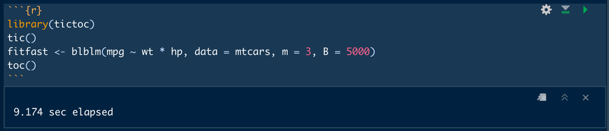

```r
knitr::include_graphics("/Users/jesusleon/Desktop/fasttictoc.png")
```

- original blblm package

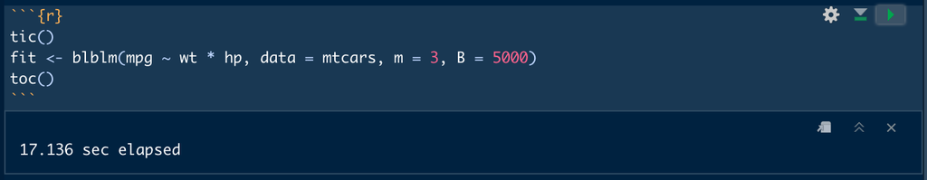

```r
knitr::include_graphics("/Users/jesusleon/Desktop/slowtictoc.png")
```